# Sports analytics

# Introduction

In this project, a study of exercise performance of the Korean population is carried out. The aim of the project consists of analysing and predicting the performance of the individuals based on different physical tests for a wide range of ages of the population, from 21 to 64 years old.

Regarding this report, it is divided as follows: firstly, the data set and the justification of the problem are presented. Secondly, the exploratory data analysis is carried out in order to get a better insight of the data set and to take the appropriate measures of correction. Then, different analysis like PCA, LDA, CART and clustering are conducted, but before that, the data is prepared for analysis, which means that it is divided into train and test sample. Finally, the results are discussed.

## Data presentation

The data was obtained from https://www.kaggle.com/kukuroo3/body-performance-data. It contains 13393 samples, and each one is defined by 11 predictors and a factor/group variable (Class).

| age | gender | height_cm | weight_kg | body fat_% | diastolic | systolic | gripForce | sit.bend_forward_cm | sit.ups_counts | broad_jump_cm | class |
| --- | --- | --- | --- | --- | --- | --- | --- | --- | --- | --- | --- |
| 27 | M | 172.3 | 75.24 | 21.3 | 80 | 130 | 54.9 | 18.4 | 60 | 217 | C |
| 25 | M | 165.0 | 55.80 | 15.7 | 77 | 126 | 36.4 | 16.3 | 53 | 229 | A |
| 31 | M | 179.6 | 78.00 | 20.1 | 92 | 152 | 44.8 | 12.0 | 49 | 181 | C |
| 32 | M | 174.5 | 71.10 | 18.4 | 76 | 147 | 41.4 | 15.2 | 53 | 219 | B |
| 28 | M | 173.8 | 67.70 | 17.1 | 70 | 127 | 43.5 | 27.1 | 45 | 217 | B |
| 36 | F | 165.4 | 55.40 | 22.0 | 64 | 119 | 23.8 | 21.0 | 27 | 153 | B |

```
##       age           gender            height_cm       weight_kg
##  Min.   :21.00   Length:13393       Min.   :125.0   Min.   : 26.30
##  1st Qu.:25.00   Class :character   1st Qu.:162.4   1st Qu.: 58.20
##  Median :32.00   Mode  :character   Median :169.2   Median : 67.40
##  Mean   :36.78                      Mean   :168.6   Mean   : 67.45
##  3rd Qu.:48.00                      3rd Qu.:174.8   3rd Qu.: 75.30
##  Max.   :64.00                      Max.   :193.8   Max.   :138.10
##    body fat_%      diastolic        systolic       gripForce
##  Min.   : 3.00   Min.   :  0.0   Min.   :  0.0   Min.   : 0.00
##  1st Qu.:18.00   1st Qu.: 71.0   1st Qu.:120.0   1st Qu.:27.50
##  Median :22.80   Median : 79.0   Median :130.0   Median :37.90
##  Mean   :23.24   Mean   : 78.8   Mean   :130.2   Mean   :36.96
##  3rd Qu.:28.00   3rd Qu.: 86.0   3rd Qu.:141.0   3rd Qu.:45.20
##  Max.   :78.40   Max.   :156.2   Max.   :201.0   Max.   :70.50
##  sit.bend_forward_cm sit.ups_counts  broad_jump_cm      class
##  Min.   :-25.00      Min.   : 0.00   Min.   :  0.0   Length:13393
##  1st Qu.: 10.90      1st Qu.:30.00   1st Qu.:162.0   Class :character
##  Median : 16.20      Median :41.00   Median :193.0   Mode  :character
##  Mean   : 15.21      Mean   :39.77   Mean   :190.1
##  3rd Qu.: 20.70      3rd Qu.:50.00   3rd Qu.:221.0
##  Max.   :213.00      Max.   :80.00   Max.   :303.0
```

These predictors could be divided into three groups:

- Personal characteristics: In which the age, gender, weight, height, fat percentage and blood pressure of each individual are recorded.
- Sport performance categories: In which the results obtained in each of the sporting events are recorded:
  - GripForce: The grip force is measured in kg. This test consists of each individual holding a dynamometer with their dominant hand and applying the highest possible grip force for 5 seconds.
  - Sit and bend forward: This is a flexibility test that consists of sitting on the floor without passing a mark and the individual has to bend as far forward as possible. Negative values might represent that the individuals could not reach the initial mark.
  - Sit-ups counts: number of complete sit-ups done in a given time.
  - Broad jump: This is a test in which the length of a static jump is measured. It is measured in cm.
- Performance: the factor variable `class` evaluates the sporting performance according to the personal characteristics of each person. This variable goes from A to D, being A the best performance and D the worst.

Once all variables are understood, it is necessary to look for missing values, which can be done using `summary` function.

```
##       age           gender            height_cm       weight_kg
##  Min.   :21.00   Length:13393       Min.   :125.0   Min.   : 26.30
##  1st Qu.:25.00   Class :character   1st Qu.:162.4   1st Qu.: 58.20
##  Median :32.00   Mode  :character   Median :169.2   Median : 67.40
##  Mean   :36.78                      Mean   :168.6   Mean   : 67.45
##  3rd Qu.:48.00                      3rd Qu.:174.8   3rd Qu.: 75.30
##  Max.   :64.00                      Max.   :193.8   Max.   :138.10
##    body fat_%      diastolic        systolic       gripForce
##  Min.   : 3.00   Min.   :  0.0   Min.   :  0.0   Min.   : 0.00
##  1st Qu.:18.00   1st Qu.: 71.0   1st Qu.:120.0   1st Qu.:27.50
##  Median :22.80   Median : 79.0   Median :130.0   Median :37.90
##  Mean   :23.24   Mean   : 78.8   Mean   :130.2   Mean   :36.96
##  3rd Qu.:28.00   3rd Qu.: 86.0   3rd Qu.:141.0   3rd Qu.:45.20
##  Max.   :78.40   Max.   :156.2   Max.   :201.0   Max.   :70.50
##  sit.bend_forward_cm sit.ups_counts  broad_jump_cm      class
##  Min.   :-25.00      Min.   : 0.00   Min.   :  0.0   Length:13393
##  1st Qu.: 10.90      1st Qu.:30.00   1st Qu.:162.0   Class :character
##  Median : 16.20      Median :41.00   Median :193.0   Mode  :character
##  Mean   : 15.21      Mean   :39.77   Mean   :190.1
##  3rd Qu.: 20.70      3rd Qu.:50.00   3rd Qu.:221.0
##  Max.   :213.00      Max.   :80.00   Max.   :303.0
```

As it can be observed, there are no `NA` values. Furthermore, besides all these variables, in order to satisfy the requirements of the assignment, it is necessary to have:

- An id
- A binary categorical variable
- Seven numerical variables
- Two polyatomic categorical variables

Therefore, in this case, the id and another categorical variable are created as follows.

```r
dt_analysis[,ID := 1:.N]
setcolorder(dt_analysis,"ID")

dt_fat <- data.table(Range1 = c(0,20,34,40),Range2 = c(20,34,40,100), catFat =
                       c("low fat","healthy","overweight","obese"))

dt_analysis[`body fat_%` < 20, catFat := "low fat"][`body fat_%`>= 20 &
           `body fat_%` < 34, catFat := "healthy"]
dt_analysis[`body fat_%` >= 34 & `body fat_%` < 40, catFat :=
          "overweight"][`body fat_%` >= 40, catFat := "obese"]

dt_analysis[, `body fat_%` := NULL]
```

In the following tables, the ranges established for the polyatomic categorical variable are presented.

Body fat categorization

| Range1 | Range2 | catFat |
| --- | --- | --- |
| 0 | 20 | low fat |
| 20 | 34 | healthy |
| 34 | 40 | overweight |
| 40 | 100 | obese |

Additionally, `gender`, `class` and `catFat` predictors are set as factors.

```
## Classes 'data.table' and 'data.frame':   13393 obs. of  13 variables:
##  $ ID                 : int  1 2 3 4 5 6 7 8 9 10 ...
##  $ age                : num  27 25 31 32 28 36 42 33 54 28 ...
##  $ gender             : Factor w/ 2 levels "F","M": 2 2 2 2 2 1 1 2 2 2 ...
##  $ height_cm          : num  172 165 180 174 174 ...
##  $ weight_kg          : num  75.2 55.8 78 71.1 67.7 ...
##  $ diastolic          : num  80 77 92 76 70 64 72 84 85 81 ...
##  $ systolic           : num  130 126 152 147 127 119 135 137 165 156 ...
##  $ gripForce          : num  54.9 36.4 44.8 41.4 43.5 23.8 22.7 45.9 40.4 57.9 ...
##  $ sit.bend_forward_cm: num  18.4 16.3 12 15.2 27.1 21 0.8 12.3 18.6 12.1 ...
##  $ sit.ups_counts     : num  60 53 49 53 45 27 18 42 34 55 ...
##  $ broad_jump_cm      : num  217 229 181 219 217 153 146 234 148 213 ...
##  $ class              : Factor w/ 4 levels "A","B","C","D": 3 1 3 2 2 2 4 2 3 2 ...
##  $ catFat             : Factor w/ 4 levels "healthy","low fat",..: 1 2 1 2 2 1 1 4 1 2 ...
##  - attr(*, ".internal.selfref")=<externalptr>
```

## Justification

In the recent years, the world is undergoing a digital transformation, where daily large amount of data are recollected in different fields. This data allows to have a better understanding of what is happening and it allows to run predictions.

A field of interest for this type of data analysis could be sport. These type of tools would allow scouts to identify athletes with a higher potential.Moreover, another important domain could be the physical health monitoring. It would allow to determine reasonable rates for healthy physical conditions.

Within this projects it is intended to carry out the following analyses:

- Determining the difference between genders.
- Determining the variables with higher contribution to the performance.
- Creating the most accurate model in order to predict the performance.
- Determining and identifying the different clusters.

Hence, the aim of this project is to obtain and analyse the results by means of different techniques (PCA, LDA, CART and RF, and clustering).

# Exploratory data analysis

First of all, the summary of the arranged dataset is displayed.

```
##       age        gender     height_cm       weight_kg        diastolic
##  Min.   :21.00   F:4926   Min.   :125.0   Min.   : 26.30   Min.   :  0.0
##  1st Qu.:25.00   M:8467   1st Qu.:162.4   1st Qu.: 58.20   1st Qu.: 71.0
##  Median :32.00            Median :169.2   Median : 67.40   Median : 79.0
##  Mean   :36.78            Mean   :168.6   Mean   : 67.45   Mean   : 78.8
##  3rd Qu.:48.00            3rd Qu.:174.8   3rd Qu.: 75.30   3rd Qu.: 86.0
##  Max.   :64.00            Max.   :193.8   Max.   :138.10   Max.   :156.2
##     systolic       gripForce     sit.bend_forward_cm sit.ups_counts
##  Min.   :  0.0   Min.   : 0.00   Min.   :-25.00      Min.   : 0.00
##  1st Qu.:120.0   1st Qu.:27.50   1st Qu.: 10.90      1st Qu.:30.00
##  Median :130.0   Median :37.90   Median : 16.20      Median :41.00
##  Mean   :130.2   Mean   :36.96   Mean   : 15.21      Mean   :39.77
##  3rd Qu.:141.0   3rd Qu.:45.20   3rd Qu.: 20.70      3rd Qu.:50.00
##  Max.   :201.0   Max.   :70.50   Max.   :213.00      Max.   :80.00
##  broad_jump_cm   class           catFat
##  Min.   :  0.0   A:3348   healthy   :7688
##  1st Qu.:162.0   B:3347   low fat   :4623
##  Median :193.0   C:3349   obese     : 192
##  Mean   :190.1   D:3349   overweight: 890
##  3rd Qu.:221.0
##  Max.   :303.0
```

Again, the data does not have missing values, thus, it is not necessary to take correction measures. Moreover, **4926** of the individuals are females, whereas the remaining **8467** are males.

The `class` feature (where A is the best) indicates the grade of performance related to age and some exercise performance data. It is divided as follows:

Class frequency table

| class | N |
| --- | --- |
| A | 3348 |
| B | 3347 |
| C | 3349 |
| D | 3349 |

Now, it is intended to find possible outliers. Firstly, from the summary, it can be observed that `gender` and `age` features have consistent values.

Now, the other features are analysed by means of the distribution of the values for each attribute broken down by gender:

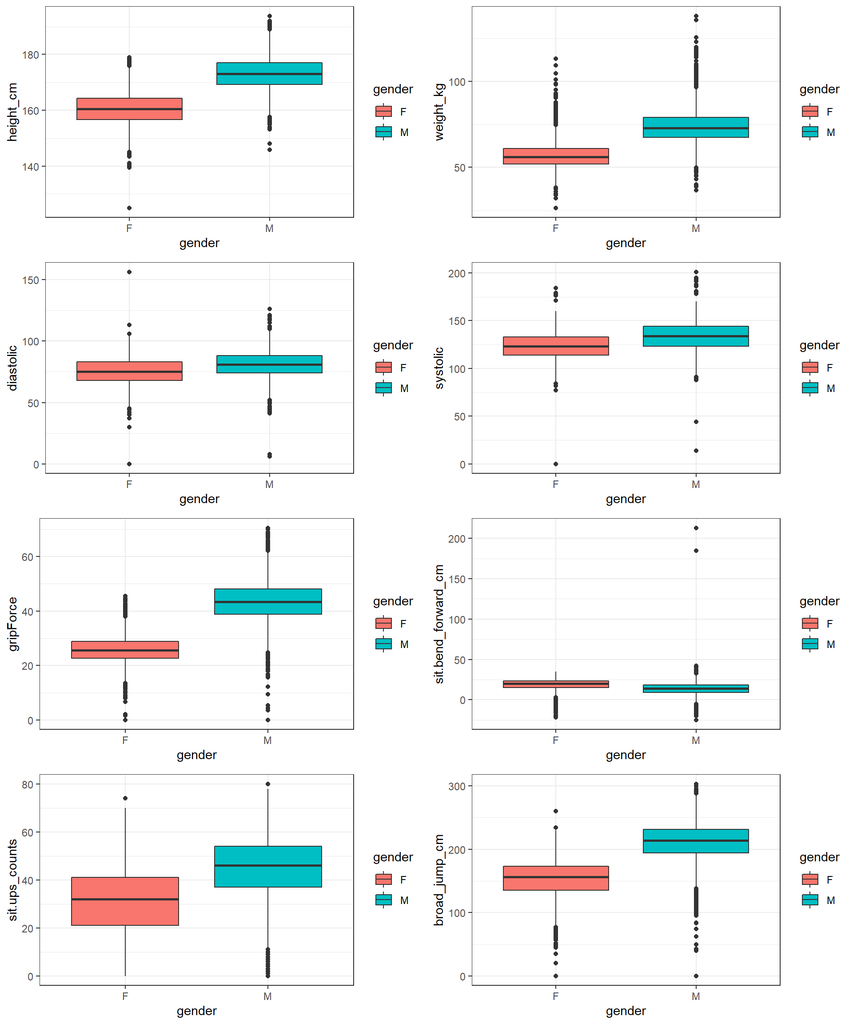

From the boxplot above, there are some potential outliers that must be investigated. Taking the example of systolic and diastolic, it can be seen how one point exceeds the 3rd quartile.

Rough conclusions can be drawn:

- Men have a slightly higher systolic and diastolic blood pressure[^1], a greater broad jump and greater strength as well as they can do a higher number of sit-ups.
- Women are more flexible.

Possible outliers are listed in the table below:

Possible outliers

| ID | age | gender | height_cm | weight_kg | diastolic | systolic | gripForce | sit.bend_forward_cm | sit.ups_counts | broad_jump_cm | class | catFat |
| --- | --- | --- | --- | --- | --- | --- | --- | --- | --- | --- | --- | --- |
| 7598 | 30 | M | 166.6 | 66.08 | 67 | 14 | 53.8 | 17.2 | 57 | 221 | A | low fat |
| 10625 | 26 | F | 160.0 | 63.56 | 0 | 0 | 23.7 | 17.1 | 23 | 128 | D | healthy |
| 8563 | 22 | F | 160.4 | 52.30 | 79 | 111 | 0.0 | 15.2 | 45 | 165 | D | overweight |
| 9487 | 45 | M | 172.4 | 56.70 | 72 | 127 | 0.0 | 9.4 | 43 | 213 | B | low fat |
| 9769 | 27 | M | 172.4 | 83.00 | 99 | 153 | 0.0 | 17.2 | 56 | 261 | C | healthy |
| 2658 | 33 | M | 165.6 | 60.40 | 81 | 127 | 38.6 | 213.0 | 53 | 244 | B | low fat |
| 3356 | 45 | M | 164.4 | 64.40 | 96 | 142 | 38.5 | 185.0 | 44 | 223 | A | healthy |
| 485 | 22 | F | 167.4 | 66.20 | 62 | 110 | 28.5 | 11.2 | 38 | 0 | C | overweight |
| 713 | 58 | M | 168.7 | 76.10 | 84 | 139 | 34.5 | 2.0 | 0 | 0 | D | healthy |
| 1920 | 59 | F | 162.9 | 61.00 | 82 | 123 | 29.7 | 19.5 | 0 | 0 | D | healthy |
| 4757 | 28 | M | 176.6 | 82.20 | 83 | 126 | 40.9 | 17.6 | 46 | 0 | C | healthy |
| 4901 | 60 | F | 162.2 | 67.30 | 47 | 131 | 22.1 | 19.5 | 0 | 0 | D | obese |
| 7367 | 50 | M | 178.2 | 88.40 | 85 | 146 | 54.9 | 19.3 | 51 | 0 | C | healthy |
| 7722 | 56 | F | 156.0 | 51.10 | 73 | 113 | 20.7 | 23.0 | 23 | 0 | C | healthy |
| 7945 | 45 | F | 153.4 | 33.70 | 81 | 124 | 6.7 | 11.5 | 8 | 0 | D | low fat |
| 7955 | 61 | F | 153.0 | 64.60 | 77 | 152 | 14.0 | 20.6 | 0 | 0 | D | healthy |
| 8600 | 60 | F | 160.0 | 76.90 | 82 | 141 | 20.1 | -8.1 | 0 | 0 | D | obese |

The possible outliers are analysed for different reasons:

- **Blood pressure (diastolic and systolic)**: In this case there are some individuals that have a too low blood pressure. This is probably because of failure of the measurement.
- **Grip force**: In this case it can be seen that there are three individuals (2 males and 1 female) that have null values, which could mean that have not done the test.
- **Sit and bend forward**: In the boxplot of this category, it can be seen that there are two points well above the average in the male gender. Analysing the two ids, 2658 and 3356, it can be seen that two people of 1.65m have reached 2.13m and 1.85m respectively in the flexibility test, so that it is impossible for this situation to occur and therefore it is considered to be a measurement error.
- **Broad jump**: Analysing this test shows that there are many null jump values. Looking individually at each of the cases it is concluded that these people have not taken the test.

**All these samples are considered outliers, thus, they are removed from the data set.**

Afterwards, the correlation between numerical variables are presented in the correlation matrix.

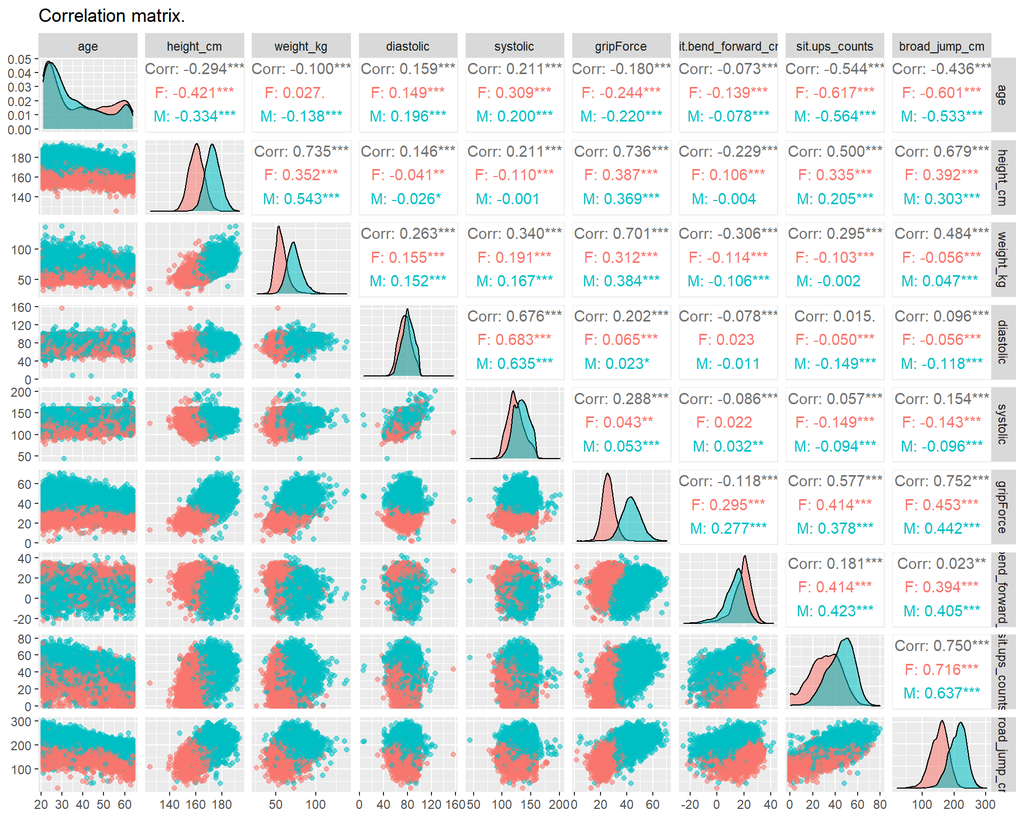

# Principal component analysis

PCs are calculated by using the `princomp` function. It has to be highlighted that the correlation matrix has been used.

In order to select the principal components, the scree plot, where the percentage of explained variance in front of the components are presented.

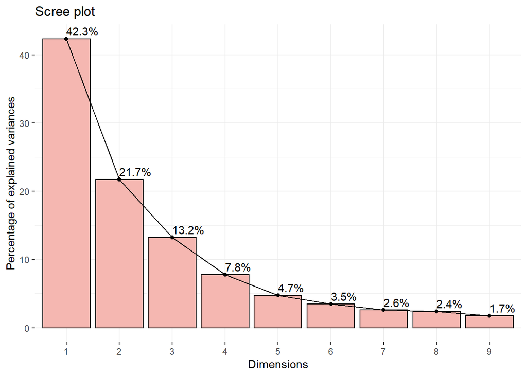

The first two PCs represent 64.1% of the original data, while first three PCs are 77.3%.

## Interpretation of PCs

Now, the contribution of each variable on the PCs is presented, as well as their interpretations.

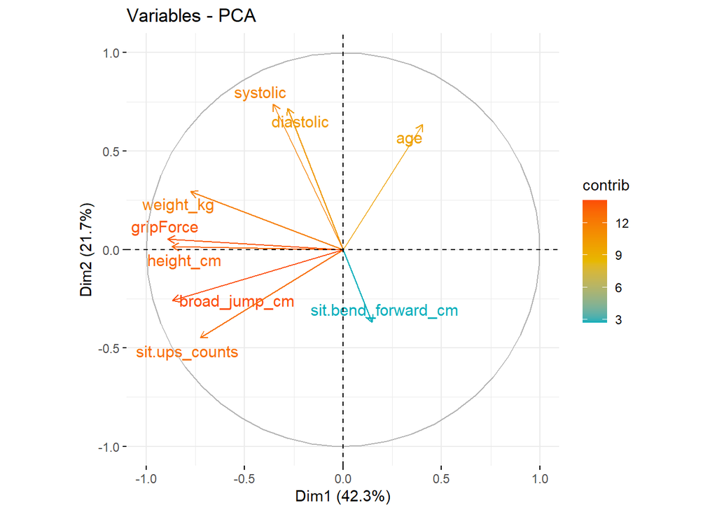

```
##
## Loadings:
##                     Comp.1 Comp.2 Comp.3 Comp.4 Comp.5 Comp.6 Comp.7 Comp.8
## age                  0.207  0.455         0.695  0.386  0.134         0.274
## height_cm           -0.445         0.220  0.104 -0.267         0.681  0.390
## weight_kg           -0.396  0.210  0.275  0.178 -0.529        -0.487
## diastolic           -0.144  0.513 -0.388 -0.357         0.656
## systolic            -0.181  0.527 -0.352 -0.144        -0.724  0.101
## gripForce           -0.456                0.314  0.165  0.103 -0.250 -0.459
## sit.bend_forward_cm        -0.264 -0.714  0.466 -0.439
## sit.ups_counts      -0.372 -0.320 -0.272         0.382        -0.360  0.632
## broad_jump_cm       -0.443 -0.184 -0.109         0.348         0.303 -0.390
##                     Comp.9
## age                  0.141
## height_cm           -0.232
## weight_kg            0.405
## diastolic
## systolic
## gripForce           -0.616
## sit.bend_forward_cm
## sit.ups_counts
## broad_jump_cm        0.616
##
##                Comp.1 Comp.2 Comp.3 Comp.4 Comp.5 Comp.6 Comp.7 Comp.8 Comp.9
## SS loadings     1.000  1.000  1.000  1.000  1.000  1.000  1.000  1.000  1.000
## Proportion Var  0.111  0.111  0.111  0.111  0.111  0.111  0.111  0.111  0.111
## Cumulative Var  0.111  0.222  0.333  0.444  0.556  0.667  0.778  0.889  1.000
```

The first component gives an overall value of the performance in the tests according to the physical characteristics (height and weight). It should be noted that this component does not take into account the flexibility test.

On the other hand, the second component gives more insight into the health status of the participants, as it provides more information on the age and blood pressure of the individuals.

Finally, the third component mainly captures the flexibility data, as expected since it is the only variable that is not over-represented in the first two components.

# Preparing data for analysis

The data is divided into train and test samples using the `createDataPartition` function. The train sample is used to train the models, while the test sample is used to validate the models.

```r
set.seed(123)
sample.ind <- createDataPartition(dt_analysis$ID, p = 0.8, list = F)

train.sample <- dt_analysis[sample.ind]
test.sample <- dt_analysis[-sample.ind]
```

Once the samples are divided, it is possible to start creating different models based on different techniques, which are presented in the sections below.

# Linear discriminant analysis

From previous sections it was observed that sample are equally separated within classes, but let’s differentiate by gender after outliers have been removed:

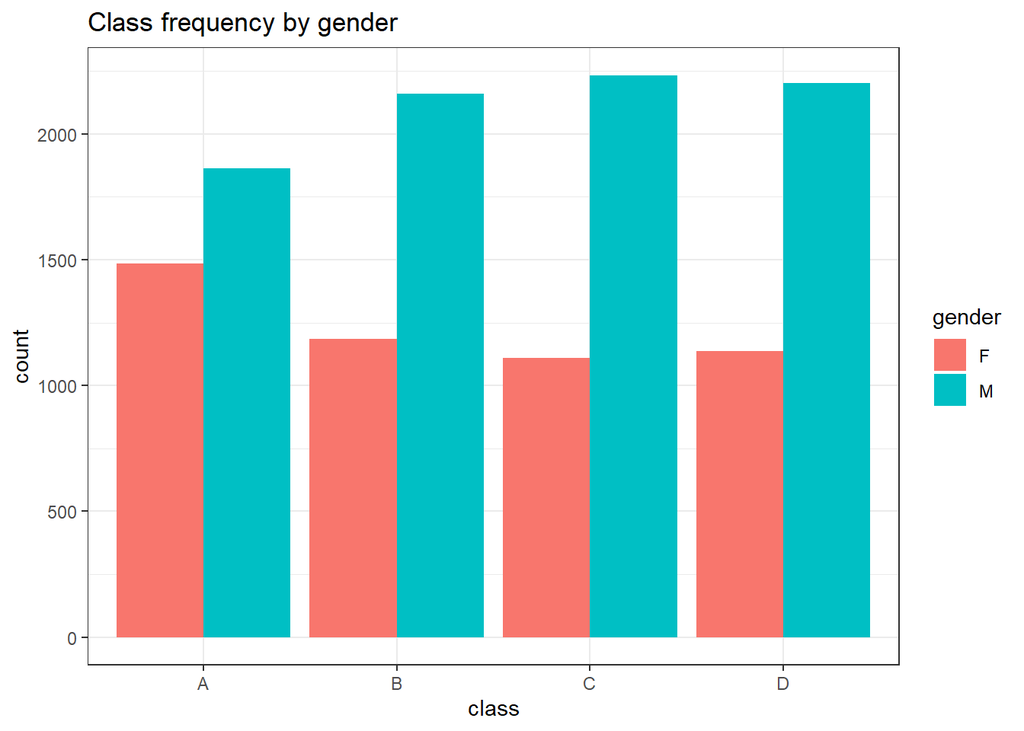

As mentioned, there are more male individuals. Moreover, for all classes except `A` they represent almost 2/3 of the class samples, while the number of male and female individuals are more similar in `A`.

Now, LDA are carried out in order to predict classes. To do so, the data set has been divided into train and test samples, as explained in previous sections.

The linear discriminant analysis is computed by means the function `lda` from *MASS package*, by using the training data subset.

```
## Call:
## lda(class ~ ., data = dt_lda_analysis)
##
## Prior probabilities of groups:
##         A         B         C         D
## 0.2509342 0.2504671 0.2471973 0.2514013
##
## Group means:
##        age height_cm weight_kg diastolic systolic gripForce sit.bend_forward_cm
## A 35.36634  167.9484  64.61724  77.97781 129.6016  38.86014           21.264732
## B 37.12831  168.5656  66.52216  78.71250 130.7777  37.90445           17.410075
## C 36.81784  169.0931  66.73106  78.45170 130.0159  36.59081           14.350276
## D 37.99591  168.6176  72.08096  80.11494 131.2917  34.72932            7.658982
##   sit.ups_counts broad_jump_cm
## A       47.90134      203.2405
## B       42.50690      195.2869
## C       38.74263      188.5170
## D       29.84563      174.2122
##
## Coefficients of linear discriminants:
##                              LD1          LD2          LD3
## age                 -0.037579110 -0.006254600  0.059268138
## height_cm           -0.003930033 -0.183995417  0.022487483
## weight_kg            0.058843188  0.117523567  0.013990941
## diastolic            0.007536690  0.011550409 -0.016103580
## systolic            -0.001148893 -0.010778395  0.031152085
## gripForce           -0.032809558 -0.010511821 -0.003731359
## sit.bend_forward_cm -0.115924706  0.019644112  0.022715954
## sit.ups_counts      -0.068558331  0.016131736 -0.015734978
## broad_jump_cm       -0.001845245  0.008301278  0.008795137
##
## Proportion of trace:
##    LD1    LD2    LD3
## 0.9861 0.0129 0.0010
```

From this function, the following statements can be concluded:

- The proportion of training observation in each group is more or less equal, around 25%.
- By the group means output, the center of gravity of each attribute per class is computed.
- The linear combination of predictor variables that are used to form the three LDA are presented.
- By means of the first linear discriminant is reached more than the 95% of the proportion of trace.

Now, the scatter visualization of the groups created by the LDA model is displayed.

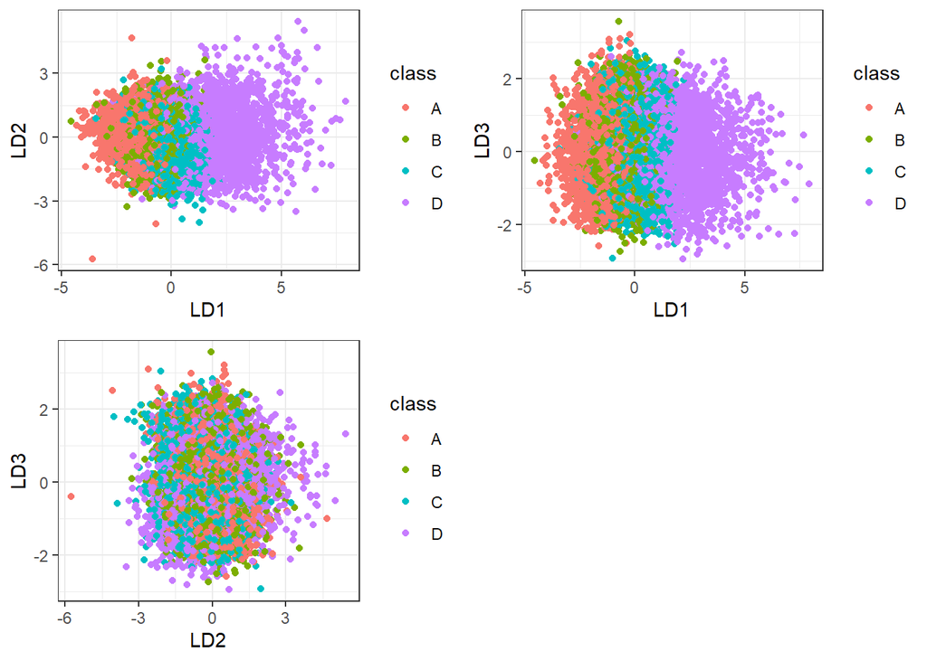

These graphs confirm what has been seen above, where LD1 provides the most information and allows differentiation between classes.

Once the model is created, the next step consists of running a prediction with the test data.

```r
prediction.lda.test <- predict(model.lda,dt_lda_analysis.test)
c.m.lda <- confusionMatrix(prediction.lda.test$class,as.factor(dt_lda_analysis.test$class))
c.m.lda$table
```

```
##           Reference
## Prediction   A   B   C   D
##          A 497 192  64  13
##          B 140 266 153  40
##          C  23 194 387 124
##          D   0  12  94 473
```

The accuracy of the LDA model is 60.74%.

## Extensions to LDA

Some extensions of LDA are used in order to see if more accurate models can be obtained.

### Quadratic discriminant analysis

Firstly, the QDA.

```
##           Reference
## Prediction   A   B   C   D
##          A 507 171  66  11
##          B 144 308 166  36
##          C   6 163 413 133
##          D   3  22  53 470
```

The accuracy of the QDA model is 63.55%.

### Flexible discriminant analysis

Secondly, the FDA.

```
##           Reference
## Prediction   A   B   C   D
##          A 497 192  64  13
##          B 140 266 153  40
##          C  23 194 387 124
##          D   0  12  94 473
```

FDA model correctly classified 60.74% of observations, which is equal to LDA model.

### Regularized discriminant analysis

Afterwards, the RDA.

```
##           Reference
## Prediction   A   B   C   D
##          A 509 174  67  11
##          B 144 308 165  35
##          C   6 161 412 133
##          D   1  21  54 471
```

The accuracy of the RDA model is 63.62%.

### Mixture discriminant analysis

Finally, the MDA.

```
##          true
## predicted   A   B   C   D
##         A 489 178  62  18
##         B 160 284 155  43
##         C  11 189 381 123
##         D   0  13 100 466
```

The accuracy of the MDA model is 60.63%.

Analysing LDA models, it can be observed that their accuracy are similar with values close to 60%. In order to find better models, CART and random forest analysis are performed.

# CART and Random forest

Since not all variables are numeric, CART and random forest allow to consider all of them. Firstly, the analysis is carried out considering a single tree, and then with random forest.

## Classification tree

Now all variables except the `ID` are considered. The first step is dividing the samples into training and testing.

```r
train.cart <- train.sample[, c(-1)]
test.cart <- test.sample[, c(-1)]
```

The model is used to predict classes. Using `rpart` function, it is possible to obtain the following tree:

```
##
## Classification tree:
## rpart(formula = class ~ ., data = train.cart, method = "class",
##     cp = 0.01)
##
## Variables actually used in tree construction:
## [1] gripForce           sit.bend_forward_cm sit.ups_counts
##
## Root node error: 8013/10704 = 0.7486
##
## n= 10704
##
##         CP nsplit rel error  xerror      xstd
## 1 0.187196      0   1.00000 1.01385 0.0055224
## 2 0.096718      1   0.81280 0.81280 0.0063020
## 3 0.037439      2   0.71609 0.71783 0.0064377
## 4 0.029327      3   0.67865 0.68177 0.0064544
## 5 0.018532      4   0.64932 0.65519 0.0064546
## 6 0.013478      6   0.61226 0.61849 0.0064381
## 7 0.010608      7   0.59878 0.60514 0.0064272
## 8 0.010000      9   0.57756 0.59541 0.0064176
```

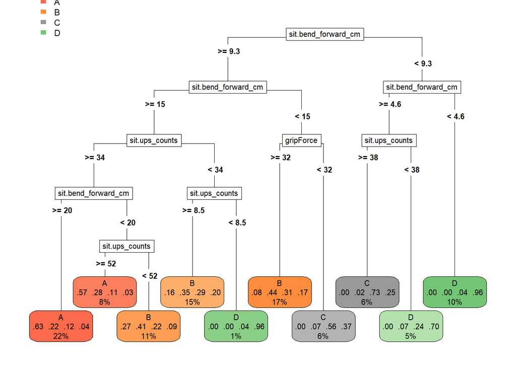

On the one hand, there are **10** terminal nodes, which are called leaves. On the other hand, the number of splits is **9** , which is the size of the tree and it is always one minus the number of the leaves.

The following table depicts the importance of each variable:

First 6 most important varibales

|  | x |
| --- | --- |
| sit.bend_forward_cm | 46 |
| sit.ups_counts | 18 |
| broad_jump_cm | 9 |
| gripForce | 8 |
| height_cm | 5 |
| gender | 5 |

It must be aware that the third most important variable is `broad_jump_cm`, however, it does not appear in the decision tree. Nevertheless, since its importance is similar to `gripForce` and both predictors are highly correlated, the obtained decision tree is taken as valid for making predictions.

```
##           Reference
## Prediction   A   B   C   D
##          A 482 191  98  27
##          B 178 447 375 173
##          C   0  16 183  97
##          D   0  10  42 353
```

The accuracy of the decision tree is 54.83%, which is a slightly lower than LDA models. The model mostly struggles predicting `C` class.

Predicted results vs real ones, 10 random rows

|  | A | B | C | D | real |
| --- | --- | --- | --- | --- | --- |
| 2463 | 62.69 | 21.68 | 12.02 | 3.61 | A |
| 2511 | 27.22 | 41.2 | 22.45 | 9.13 | B |
| 2227 | 0 | 0 | 3.84 | 96.16 | D |
| 526 | 7.84 | 44.26 | 31.09 | 16.81 | B |
| 195 | 7.84 | 44.26 | 31.09 | 16.81 | B |
| 1842 | 0 | 0 | 3.84 | 96.16 | D |
| 1142 | 7.84 | 44.26 | 31.09 | 16.81 | D |
| 1253 | 27.22 | 41.2 | 22.45 | 9.13 | B |
| 1268 | 15.73 | 34.91 | 29.28 | 20.08 | B |
| 1038 | 62.69 | 21.68 | 12.02 | 3.61 | A |

## Random forest

Decision trees is a powerful tool for categorization, but the model can be improved even more using random forest, since this method uses multiple trees. In this case, it has been decided to create different models considering different number of variables tied at each split `for(i in 2:6)`. All the models are displayed below:

```
## [[1]]
##
## Call:
##  randomForest(formula = class ~ ., data = train.cart, ntree = 1000,      mtry = i)
##                Type of random forest: classification
##                      Number of trees: 1000
## No. of variables tried at each split: 2
##
##         OOB estimate of  error rate: 27.49%
## Confusion matrix:
##      A    B    C    D class.error
## A 2285  367   29    5   0.1492926
## B  620 1634  344   83   0.3905259
## C  219  537 1663  227   0.3715042
## D   31  136  344 2180   0.1898922
##
## [[2]]
##
## Call:
##  randomForest(formula = class ~ ., data = train.cart, ntree = 1000,      mtry = i)
##                Type of random forest: classification
##                      Number of trees: 1000
## No. of variables tried at each split: 3
##
##         OOB estimate of  error rate: 26.65%
## Confusion matrix:
##      A    B    C    D class.error
## A 2314  341   27    4   0.1384959
## B  603 1675  335   68   0.3752331
## C  217  545 1698  186   0.3582766
## D   36  137  354 2164   0.1958380
##
## [[3]]
##
## Call:
##  randomForest(formula = class ~ ., data = train.cart, ntree = 1000,      mtry = i)
##                Type of random forest: classification
##                      Number of trees: 1000
## No. of variables tried at each split: 4
##
```

[output cut: 24 more lines]

```
## [[5]]
##
## Call:
##  randomForest(formula = class ~ ., data = train.cart, ntree = 1000,      mtry = i)
##                Type of random forest: classification
##                      Number of trees: 1000
## No. of variables tried at each split: 6
##
##         OOB estimate of  error rate: 25.78%
## Confusion matrix:
##      A    B    C    D class.error
## A 2348  308   28    2   0.1258377
## B  601 1750  266   64   0.3472585
## C  231  543 1701  171   0.3571429
## D   34  153  359 2145   0.2028986
```

The model with less estimate of error rate is the one with 6 variables at each split. Now, let’s see how many trees would be necessary.

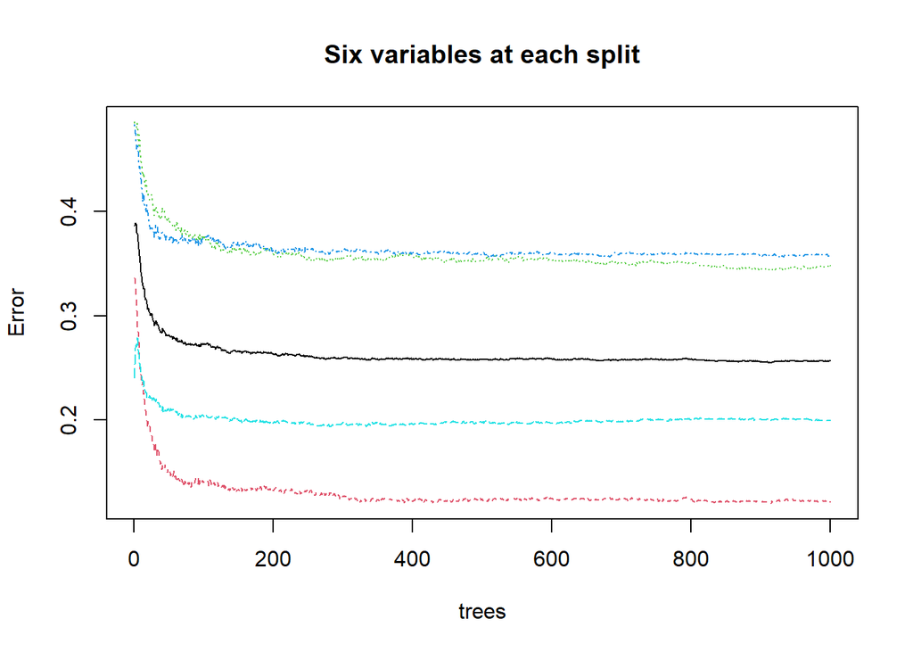

It can be observed that the error rate from 300 trees remains almost constant, therefore, using more trees would be a waste of computational resources.

Now, the predictions are run with the random forest model considering 6 variables per split and 300 trees.

```
##           Reference
## Prediction   A   B   C   D
##          A 568 159  55  13
##          B  80 402 150  42
##          C   9  84 462  81
##          D   3  19  31 514
```

Now, the accuracy of the model is 72.83%.

# Clustering

The last part of this project consists of clustering. The case study of this method will be divided into three main methods: `Hierarchical`, `K-means` and `Model-based` clustering as well as a mixture of them.

The main objective of clustering is to classify the data set into groups with similar attributes.

In order to reduce computational time and being able to understand the results, it has been decided to carry out the analysis considering only 1000 random samples.

It must be aware that clustering is based on distances. Therefore, only numeric variables are considered and they must be scaled in order to avoid dominance of some variables over others. Only for hierarchical and k-means cluster is necessary, however, this is done throughout all analysis, since it will allow to make comparisons.

The summary of the data subset is displayed below.

```
##       age            height_cm          weight_kg          diastolic
##  Min.   :-1.2011   Min.   :-2.88309   Min.   :-3.42729   Min.   :-3.38762
##  1st Qu.:-0.9076   1st Qu.:-0.73524   1st Qu.:-0.78888   1st Qu.:-0.65383
##  Median :-0.3207   Median : 0.07461   Median : 0.02579   Median : 0.05166
##  Mean   : 0.0000   Mean   : 0.00000   Mean   : 0.00000   Mean   : 0.00000
##  3rd Qu.: 0.8532   3rd Qu.: 0.74362   3rd Qu.: 0.66678   3rd Qu.: 0.66897
##  Max.   : 1.9537   Max.   : 2.77410   Max.   : 4.20671   Max.   : 6.77149
##     systolic           gripForce        sit.bend_forward_cm sit.ups_counts
##  Min.   :-2.722157   Min.   :-2.59797   Min.   :-4.0740     Min.   :-2.72607
##  1st Qu.:-0.737065   1st Qu.:-0.85685   1st Qu.:-0.5283     1st Qu.:-0.63563
##  Median :-0.009198   Median : 0.05115   Median : 0.1212     Median : 0.06118
##  Mean   : 0.000000   Mean   : 0.00000   Mean   : 0.0000     Mean   : 0.00000
##  3rd Qu.: 0.784839   3rd Qu.: 0.74385   3rd Qu.: 0.7004     3rd Qu.: 0.75799
##  Max.   : 3.960987   Max.   : 3.14022   Max.   : 2.3855     Max.   : 2.70907
##  broad_jump_cm
##  Min.   :-4.32752
##  1st Qu.:-0.70046
##  Median : 0.09137
##  Mean   : 0.00000
##  3rd Qu.: 0.78102
##  Max.   : 2.39021
```

Once variables have been scaled, it can be observed that the mean of each predictor is zero. Moreover, the standard deviation is one, as it can be checked below.

```r
apply(dt_clustering, 2, sd)
```

```
##                 age           height_cm           weight_kg           diastolic
##                   1                   1                   1                   1
##            systolic           gripForce sit.bend_forward_cm      sit.ups_counts
##                   1                   1                   1                   1
##       broad_jump_cm
##                   1
```

Now that the variables are scaled, the next step consists of computing the distance matrix using the `euclidean` method.

```r
dt_clustering.D <- dist(dt_clustering, method = "euclidean")
```

## Agglomerative hierarchical clustering

Taking into consideration that `agnes` and `hclust` are quite similar models, it has been decided to use only the first one, since it provides information about the agglomerative coefficient, which measures the amount of clustering structure. Note that closer values to 1 suggest strong clustering structures.

All linkage methods are compared in order to obtain the maximum agglomerative coefficient.

```
##   average    single  complete      ward
## 0.8453418 0.7948785 0.8880889 0.9820664
```

As ward method has the highest agglomerative coefficient (strongest clustering structure), it is used to carry out the analysis. So, the dendrogram is created using ward method.

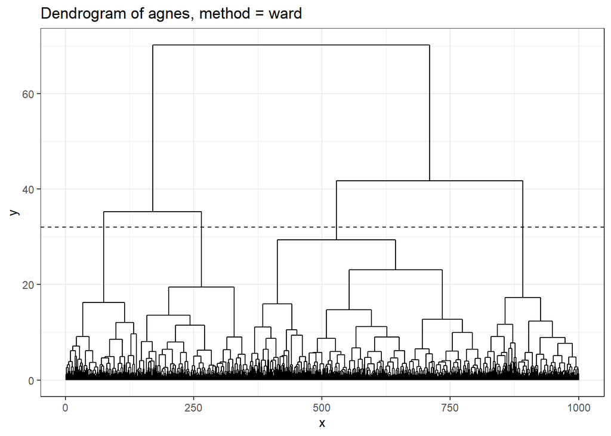

Cutting the dendrogram at a height of 32, it is possible to identify four branches, therefore, four clusters are considered as initial hypothesis. However, this will be studied in more detail in posterior sections.

Now, let’s try to visualize clusters more clearly.

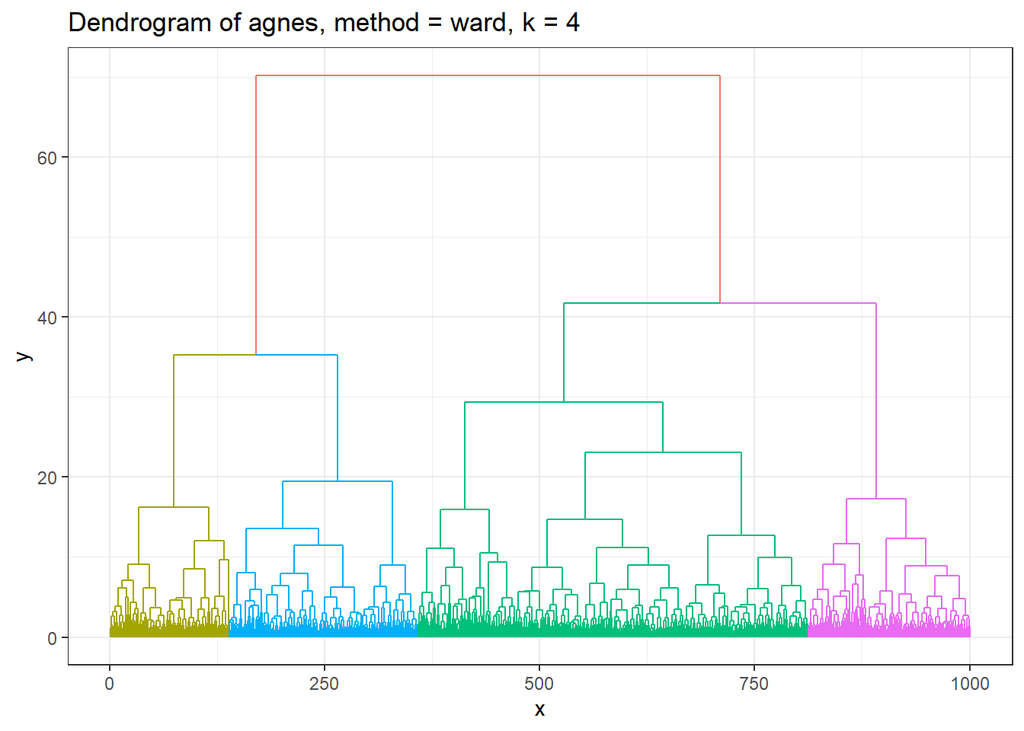

### Hierarchical clustering on principal components

Another approach is combining PCA and later apply clustering methods in the case of continuous variables. By means of adding the PCA step before, noise can be mitigated leading to a more stable clustering.

A simple way to decide the number of clusters is using the inertia plot.

In the inertia plot shown below, it can be seen that four is the optimal number of clusters. From 4 to 5 clusters, it has been assessed that there are no important losses. Note that is the same number as the one defined in the previous section.

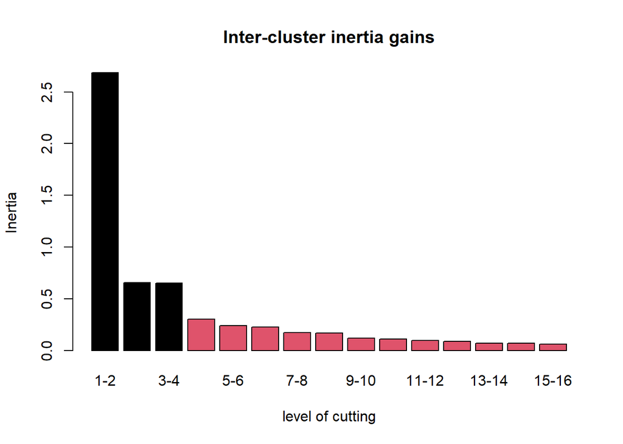

```
## [1] 1 3 2 4
## Levels: 1 2 3 4
```

Afterwards, the dendrogram and the individuals factor map are displayed below.

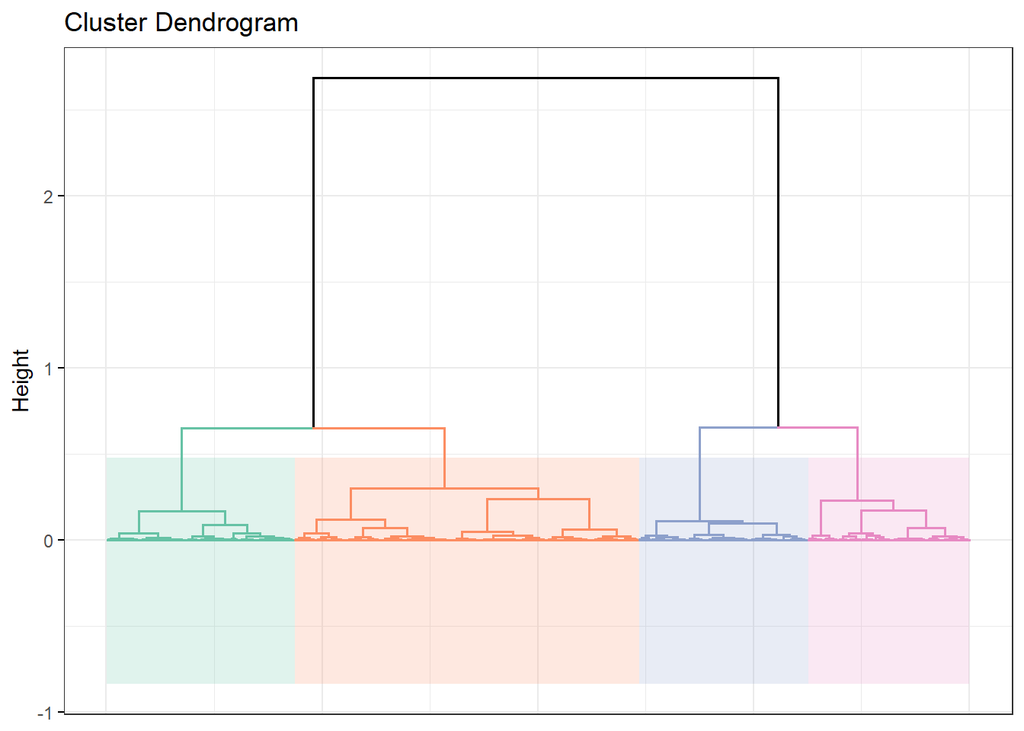

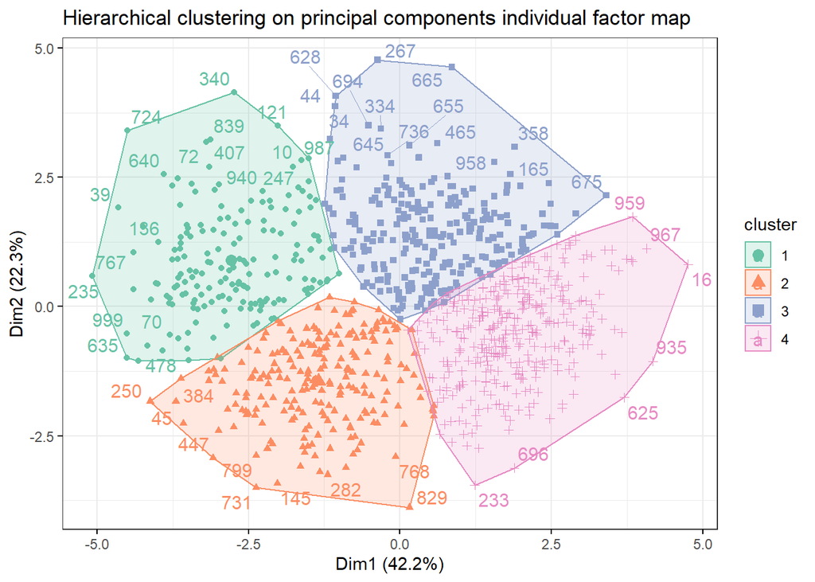

Additionally, the mean of each variable per cluster is presented. It can be observed the difference between clusters is quite pronounced.

| cluster | age | height_cm | weight_kg | diastolic | systolic | gripForce | sit.bend_forward_cm | sit.ups_counts | broad_jump_cm |
| --- | --- | --- | --- | --- | --- | --- | --- | --- | --- |
| 1 | 1.1449770 | -1.2330720 | -0.7990779 | 0.0303523 | 0.0952206 | -1.1219303 | -0.0061891 | -1.3912508 | -1.3834644 |
| 2 | -0.5036289 | -0.6719500 | -0.9012522 | -0.6973449 | -0.9070074 | -0.8225088 | 0.5722732 | -0.0042036 | -0.4306269 |
| 3 | 0.5421886 | 0.3498917 | 0.5501752 | 0.7304519 | 0.7753489 | 0.3223525 | -0.5514510 | -0.2380883 | 0.0295956 |
| 4 | -0.6299330 | 0.7966512 | 0.5866210 | -0.0868111 | -0.0148855 | 0.8592922 | 0.0274467 | 0.8636125 | 0.9445936 |

## Partitioning clustering: k-means

The next method used to study clustering is k-means. In this case, it is necessary to define the number of clusters previously, therefore, the results for different number of clusters represented.

The final k-means clustering solution is very sensitive to this initial conditions. In other words, the result might be slightly different each time you compute k-means as this method selects initial centroids randomly.

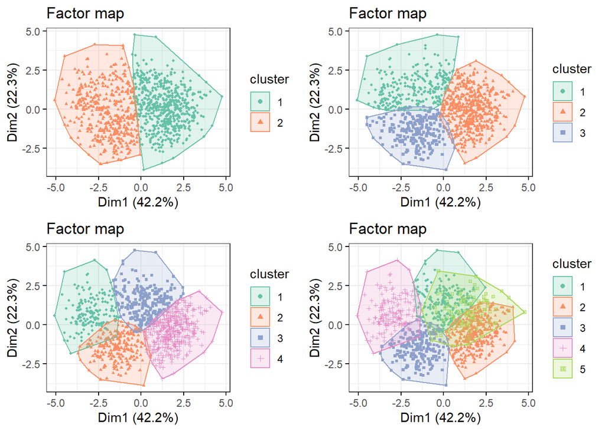

In the figure above it can be seen that the samples can be clearly differentiated in two, three and four clusters. However, for five clusters, they start overlapping. In order to estimate the optimal number of clusters, different methods are used.

### Elbow method

Firstly, the Elbow method for k-means is computed. As it can be seen in the graph, the elbow point corresponds to 4 clusters. From 4 clusters onwards, the total within sum of the square curve decreases more slowly.

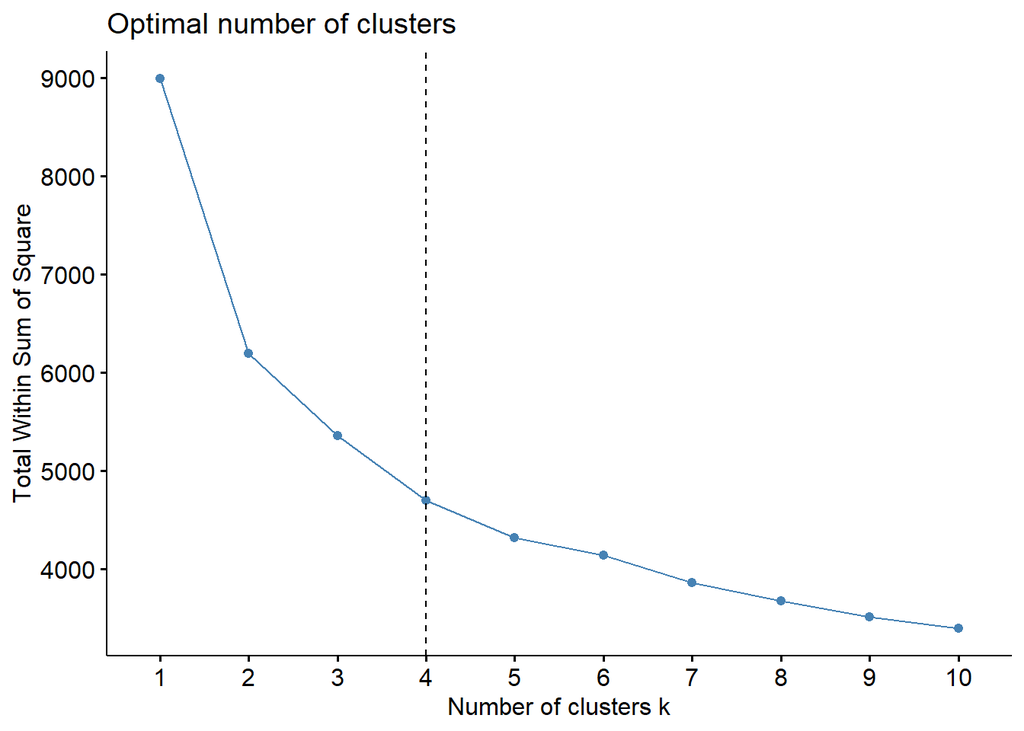

### Silhouette method

Another method is the average silhouette method. It determines how well each object lies within its cluster. In this case, the optimal number of clusters is the one that maximizes the average silhouette, where the silhouette coefficient for a sample is $\frac{b-a}{max(a,b)}$. Hence, for this particular case study, the optimal number of clusters is 2.

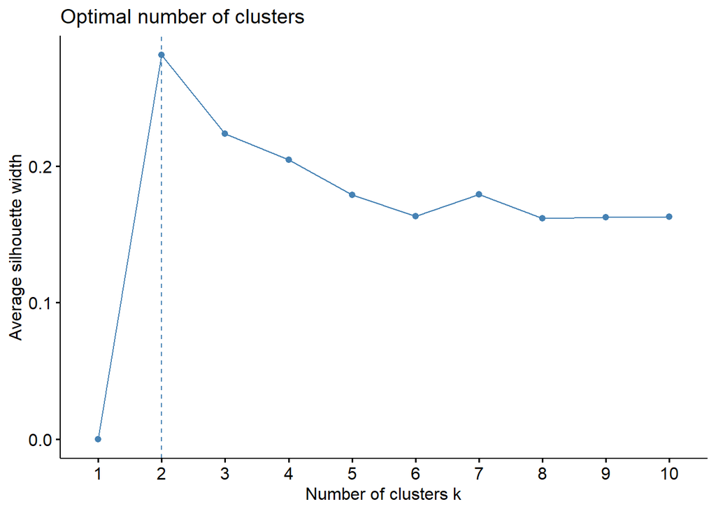

### Gap statistic method

In contrast to the methods mentioned before, the gap statistic is a statistical testing method, which means comparing evidence against null hypothesis. It can be visualized by using the `fviz_gap_stat` function. This method suggests 6 as the optimal number of clusters.

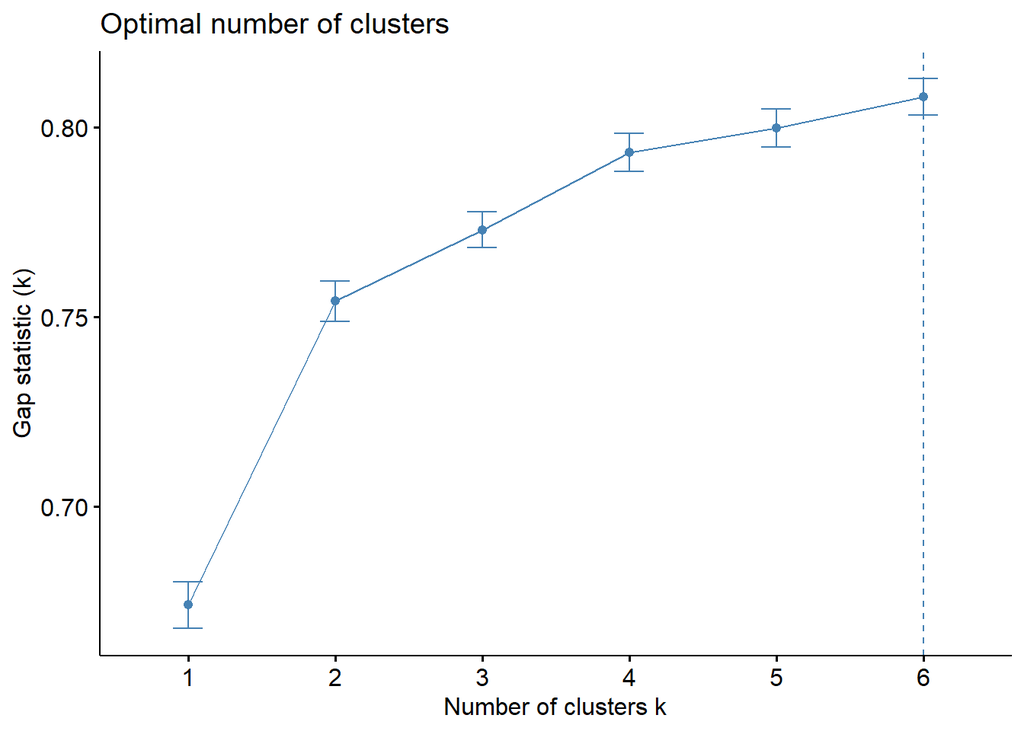

### Nbclust

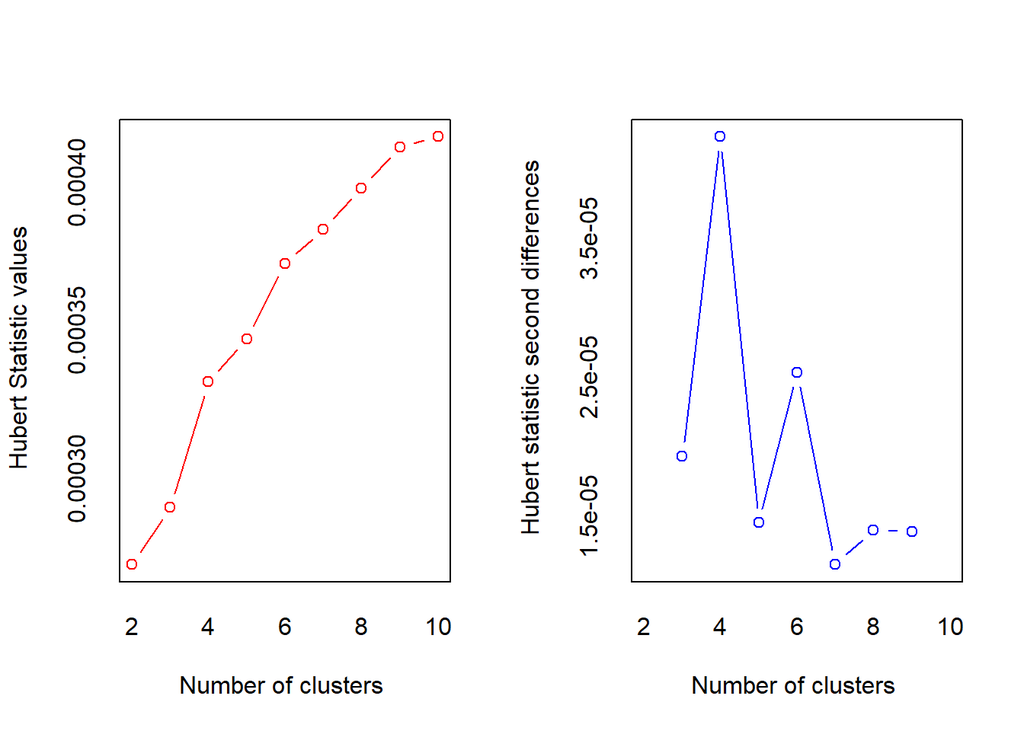

```
## *** : The Hubert index is a graphical method of determining the number of clusters.
##                 In the plot of Hubert index, we seek a significant knee that corresponds to a
##                 significant increase of the value of the measure i.e the significant peak in Hubert
##                 index second differences plot.
##
```

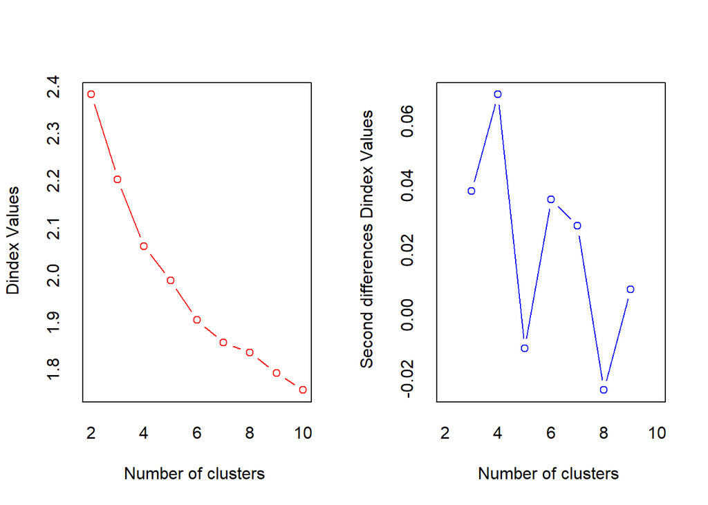

```
## *** : The D index is a graphical method of determining the number of clusters.
##                 In the plot of D index, we seek a significant knee (the significant peak in Dindex
##                 second differences plot) that corresponds to a significant increase of the value of
##                 the measure.
##
## * Among all indices:
## * 10 proposed 2 as the best number of clusters
## * 4 proposed 3 as the best number of clusters
## * 6 proposed 4 as the best number of clusters
## * 1 proposed 5 as the best number of clusters
## * 1 proposed 7 as the best number of clusters
## * 1 proposed 10 as the best number of clusters
##
##                    ***** Conclusion *****
##
## * According to the majority rule, the best number of clusters is  2
##
##
```

### Comparison

To sum up, it has been obtained the following models results:

- Silhouette method and NbClust suggest 2 as the number of optimal clusters.
- The Elbow point corresponds to 4 clusters.
- Gap statistic method proposes 6 as the number of optimal clusters.

However, the most important method is the common sense of the clusters. For this reason, the mean and the cluster sizes are computed.

Regarding to the size of the clusters, both cases are reasonable.

2 clusters

4 clusters

583

158

417

220

236

386

Now, let’s look at the means. Dividing the dataset into 2 clusters.

| Cluster | age | height_cm | weight_kg | diastolic | systolic | gripForce | sit.bend_forward_cm | sit.ups_counts | broad_jump_cm |
| --- | --- | --- | --- | --- | --- | --- | --- | --- | --- |
| 1 | -0.2406547 | 0.6440237 | 0.5773740 | 0.1976293 | 0.2515089 | 0.6596002 | -0.1840251 | 0.4785504 | 0.6269296 |
| 2 | 0.3364550 | -0.9003977 | -0.8072159 | -0.2763019 | -0.3516300 | -0.9221748 | 0.2572821 | -0.6690525 | -0.8764988 |

Dividing the dataset into 4 clusters.

| Cluster | age | height_cm | weight_kg | diastolic | systolic | gripForce | sit.bend_forward_cm | sit.ups_counts | broad_jump_cm |
| --- | --- | --- | --- | --- | --- | --- | --- | --- | --- |
| 1 | 1.2237566 | -1.2857576 | -0.8567585 | -0.1475976 | 0.0356136 | -1.1510062 | 0.0181950 | -1.4259410 | -1.4439420 |
| 2 | -0.5771485 | -0.6941037 | -0.9245271 | -0.6490241 | -0.8820367 | -0.8694967 | 0.5967059 | -0.0129354 | -0.4555952 |
| 3 | 0.7328885 | 0.1866098 | 0.4108085 | 0.7497552 | 0.7113798 | 0.2055238 | -0.4899016 | -0.3285624 | -0.0767176 |
| 4 | -0.6200584 | 0.8078047 | 0.6264586 | -0.0280738 | 0.0532008 | 0.8410483 | -0.0480138 | 0.7919305 | 0.8976144 |

As the majority of the means of the predictors of the 4 clusters differs, it has been considered convenient to divide the dataset into 4 clusters.

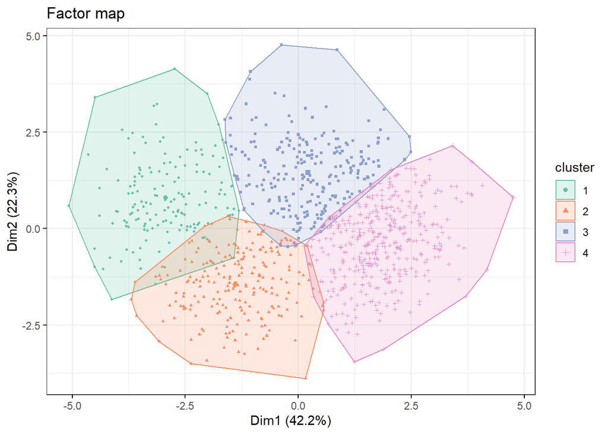

## Hierarchical k-means clustering

Another approach is the combination of the hierarchical method and the k-means one. As it is mentioned before, a limitation of the k-means clustering is the dependence to the initial conditions, as it selects initial centroids randomly. Hence, a solution to improve this limitation is to mix both methods.

The algorithm is summarized into:

1. Compute hierarchical clustering and cut the tree into k-clusters.
2. Compute the centroid of each cluster.
3. Compute k-means method by means of the set of cluster centers defined previously as the initial cluster centers.

The dendrogram as well as the hierarchical k-means clusters are displayed below.

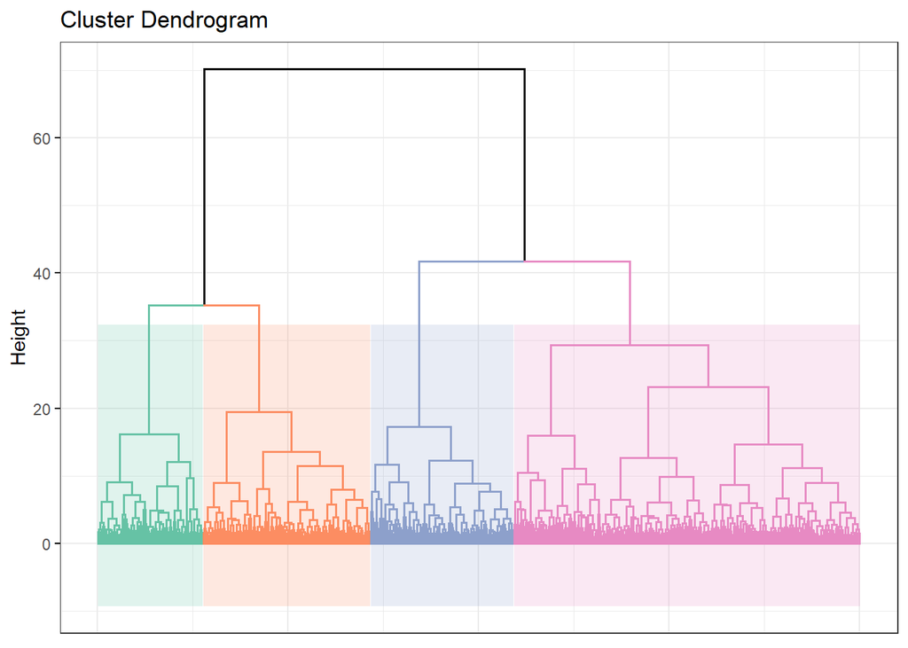

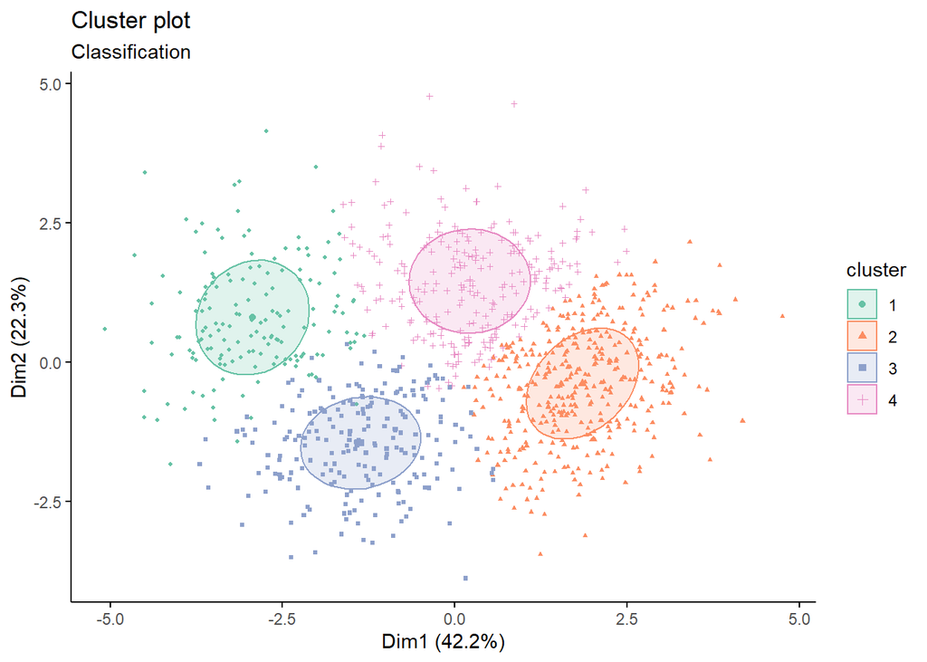

## Model-based clustering

Finally, the last method is the model-based clustering. It consists of a soft clustering, which means that each data point has a probability of belonging to each cluster.

The added value of this method is the different possible parametrizations of the clusters providing properly identification of them, since the data is considered as coming from a mixture of Gaussian distribution models.

It must be remarked that the algorithm uses a principal component analysis to reduce the dimensionality of the data as the dataset has more than two variables.

```
## ----------------------------------------------------
## Gaussian finite mixture model fitted by EM algorithm
## ----------------------------------------------------
##
## Mclust VEE (ellipsoidal, equal shape and orientation) model with 5 components:
##
##  log-likelihood    n df      BIC       ICL
##       -9698.919 1000 98 -20074.8 -20292.21
##
## Clustering table:
##   1   2   3   4   5
## 152 109 198 154 387
```

For this data, it can be seen that the model-based clustering selects a model with 5 clusters. The optimal selected model name is VEE model, which means ellipsoidal, equal shape and orientation.

In order to estimate the number of clusters, the model-based clustering usually uses the BIC parameter, which depends on the number of parameters in the model.

The BIC values used for choosing the number of clusters is presented below.

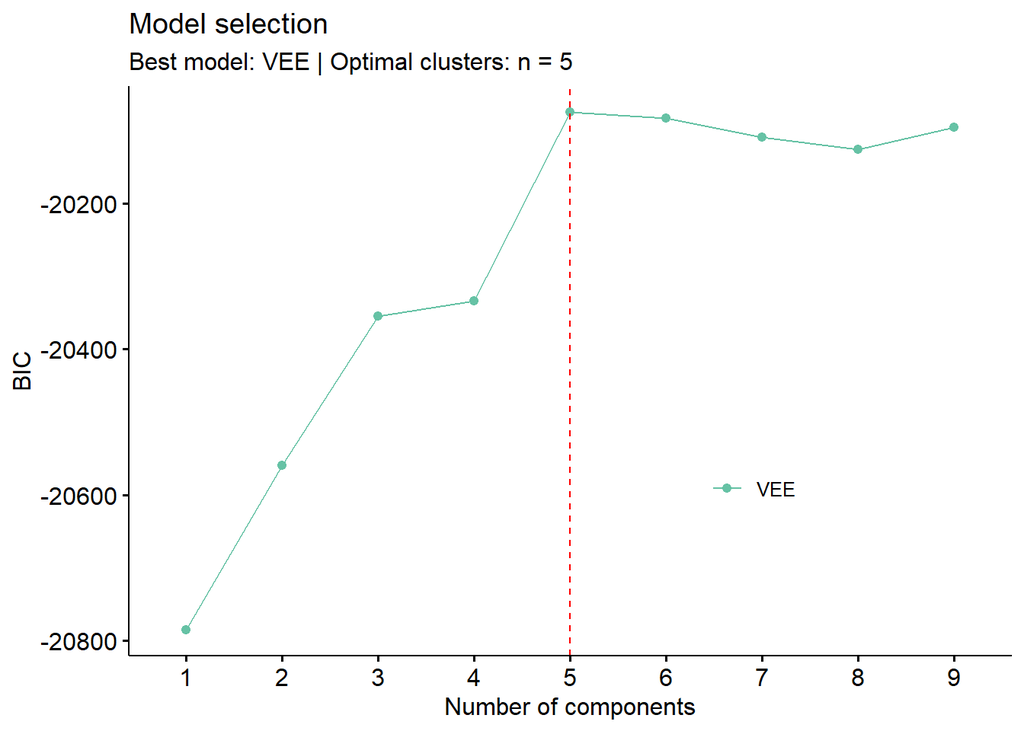

The model-based clusters are presented below.

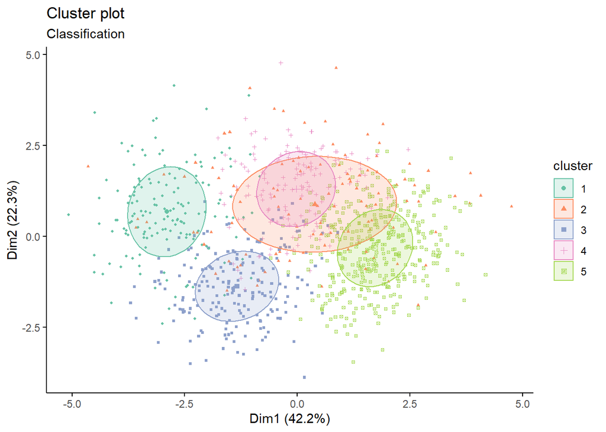

As it can be seen in the figure, five clusters induce to an overlapping. Thus, let’s compute the size of each cluster.

```
##
##   1   2   3   4   5
## 152 109 198 154 387
```

The size of cluster number two is rather small, thus, the number of clusters is forced to be 4. Below is displayed the summary.

```
## ----------------------------------------------------
## Gaussian finite mixture model fitted by EM algorithm
## ----------------------------------------------------
##
## Mclust EEE (ellipsoidal, equal volume, shape and orientation) model with 4
## components:
##
##  log-likelihood    n df       BIC       ICL
##       -9852.821 1000 84 -20285.89 -20418.25
##
## Clustering table:
##   1   2   3   4
## 153 179 229 439
```

The four model-based clusters are presented below.

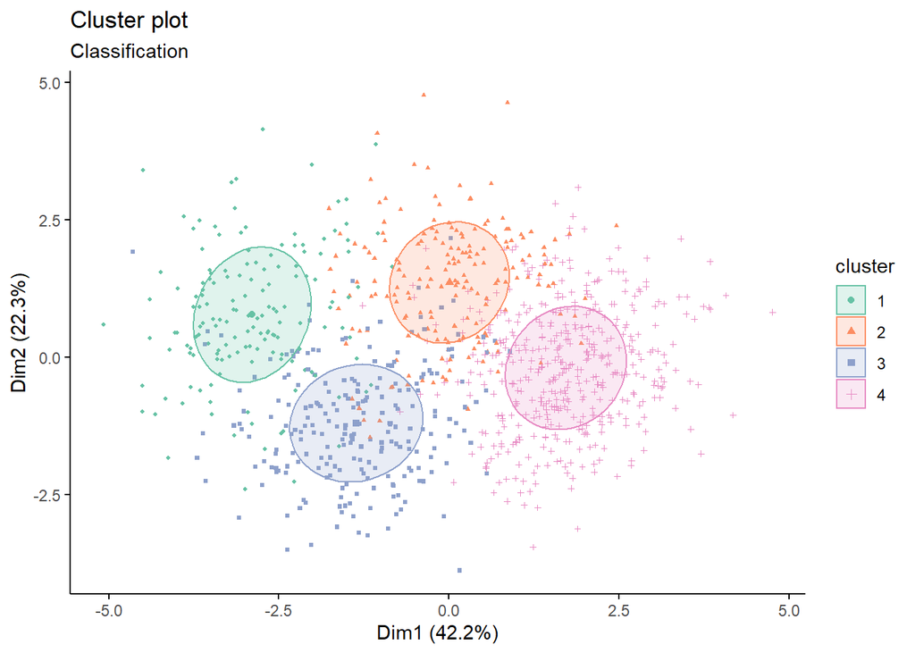

In this case, the parametrization of the clusters is carried out by the EEE model (ellipsoidal, equal volume, shape and orientation.

The probabilities to belong to a given cluster of 15 random samples are listed below.

Probability to belong to a given cluster (sample of 15)

| Cluster 1 | Cluster 2 | Cluster 3 | Cluster 4 | Cluster |
| --- | --- | --- | --- | --- |
| 0.0000000 | 0.0000028 | 0.0000162 | 0.9999810 | 4 |
| 0.0000000 | 0.0000110 | 0.0001308 | 0.9998582 | 4 |
| 0.8469586 | 0.1253553 | 0.0266707 | 0.0010154 | 1 |
| 0.0000000 | 0.0001101 | 0.0008701 | 0.9990198 | 4 |
| 0.0000000 | 0.0000049 | 0.0000639 | 0.9999312 | 4 |
| 0.0041647 | 0.7195168 | 0.0066753 | 0.2696433 | 2 |
| 0.0001444 | 0.0073533 | 0.0537311 | 0.9387711 | 4 |
| 0.0150265 | 0.0000066 | 0.9849481 | 0.0000188 | 3 |
| 0.0000052 | 0.0000002 | 0.9994343 | 0.0005603 | 3 |
| 0.0000000 | 0.0000036 | 0.0000753 | 0.9999211 | 4 |
| 0.0000218 | 0.0000001 | 0.9998944 | 0.0000837 | 3 |
| 0.8120886 | 0.0036801 | 0.1841449 | 0.0000865 | 1 |
| 0.7258900 | 0.0007624 | 0.2733226 | 0.0000249 | 1 |
| 0.0000131 | 0.9999595 | 0.0000000 | 0.0000275 | 2 |
| 0.6797067 | 0.2916835 | 0.0264800 | 0.0021299 | 1 |

| Cluster | age | height_cm | weight_kg | diastolic | systolic | gripForce | sit.bend_forward_cm | sit.ups_counts | broad_jump_cm |
| --- | --- | --- | --- | --- | --- | --- | --- | --- | --- |
| 1 | 1.2873355 | -1.2735464 | -0.8469997 | -0.1238818 | 0.0522771 | -1.1202974 | 0.2111964 | -1.3074778 | -1.3750986 |
| 2 | 1.1677565 | 0.1126038 | 0.2595536 | 0.4776205 | 0.5562945 | 0.2613850 | -0.3509738 | -0.2954959 | -0.0404385 |
| 3 | -0.6846836 | -0.6799260 | -0.8652083 | -0.4436654 | -0.6874860 | -0.9237111 | 0.5392375 | -0.0991529 | -0.5601265 |
| 4 | -0.5915150 | 0.7481618 | 0.6308547 | 0.0706760 | 0.0998541 | 0.7562342 | -0.2027760 | 0.6344691 | 0.7867034 |

Some conclusions can be drawn from the means of each cluster:

- **Cluster 1**: Older, smaller and lighter people with low performance on physical activities. Probably old women.
- **Cluster 2**: Older, taller, heavier people with higher blood pressure and bad performance. Probably old men.
- **Cluster 3**: Younger, smaller, lighter people with low pressure and low performance on physical activities except flexibility. Probably young women.
- **Cluster 4**: Younger, taller and heavier people with good physical performance, but with low flexibility. Probably young men.

# Conclusions

To sum up, all the objectives of the project have been fulfilled, since it has been possible to conduct different analysis using different techniques such as PCA, LDA, CART clustering.

On the one hand, for supervised methods, the model with the highest accuracy is random forest, up to 72%. Note that in this case the output was a categorical value, therefore, miss-classification between categories is not so relevant as in binary cases.

Finally, the data set has been divided into four different clusters based on age and gender.

[^1]: Diastolic: blood pressure related to the relaxation process of the heart.  
    Systolic: blood pressure related to the contraction process of the heart.